# Income and BMI Patterns in NHANES Adults

Cedar Equity Lab

## Audience and KT purpose

**Audience:** Municipal public-health staff preparing an internal health-equity briefing.

**Purpose:** Show one descriptive income-group pattern, keep its limits visible, and identify the next question before the result is used in discussion.

## Question

How does mean BMI differ across income groups among adults age 20-80 in the prepared NHANES Health Equity classroom dataset?

Why it matters: a clear descriptive comparison can help staff decide whether a survey-aware follow-up analysis is warranted.

## Data and sample

- Prepared classroom CSV derived from CDC/NCHS NHANES public-use files
- 105,626 prepared records
- 57,137 records after the inclusive age 20-80 restriction
- 1,009 adult records missing BMI and 5,395 missing income group before complete-case selection
- Aggregate, unweighted classroom analysis; no row-level data shared with AI

## Main evidence

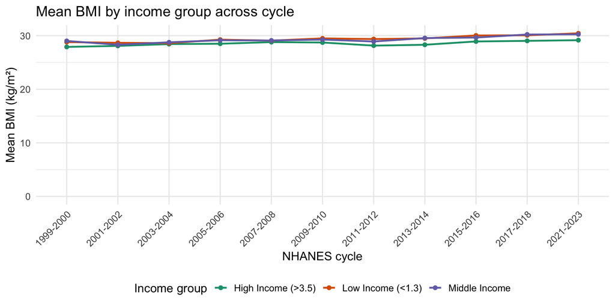

Mean BMI by income group across available NHANES cycles. Unweighted descriptive classroom results; not population estimates.

## Interpretation and limitation

Overall mean BMI was approximately:

- 28.6 in the high-income group;
- 29.4 in the low-income group; and
- 29.3 in the middle-income group.

The difference is small. These summaries are descriptive and unweighted. They do not show that income causes BMI differences or estimate the US population.

## Practical implication and next step

Use the result to ask a better question, not to rank groups:

> Does this small pattern remain after using the appropriate NHANES survey design and examining missing records?

For this course project, the responsible conclusion is that the prepared data show a modest descriptive difference that needs survey-aware follow-up.

Source: CDC/NCHS NHANES public-use data, prepared classroom snapshot.